# Supervised Learning - Foundations Project: ReCell

### TEST FOR LINEARITY AND INDEPENDENCE

**Why the test?**

- Linearity describes a straight-line relationship between two variables, predictor variables must have a linear relation with the dependent variable.
- The independence of the error terms (or residuals) is important. If the residuals are not independent, then the confidence intervals of the coefficient estimates will be narrower and make us incorrectly conclude a parameter to be statistically significant.

**How to check linearity and independence?**

- Make a plot of fitted values vs residuals.
- If they don't follow any pattern, then we say the model is linear and residuals are independent.
- Otherwise, the model is showing signs of non-linearity and residuals are not independent.

**How to fix if this assumption is not followed?**

- We can try to transform the variables and make the relationships linear.

```python
# let us create a dataframe with actual, fitted and residual values
df_pred = pd.DataFrame()

df_pred["Actual Values"] = y_train  # actual values
df_pred["Fitted Values"] = olsmod2.fittedvalues  # predicted values
df_pred["Residuals"] = olsmod2.resid  # residuals

df_pred.head()
```

|  | Actual Values | Fitted Values | Residuals |
| --- | --- | --- | --- |
| 3026 | 4.087488 | 3.858480 | 0.229008 |
| 1525 | 4.448399 | 4.588663 | -0.140263 |
| 1128 | 4.315353 | 4.277413 | 0.037940 |
| 3003 | 4.282068 | 4.274621 | 0.007447 |
| 2907 | 4.456438 | 4.463744 | -0.007305 |

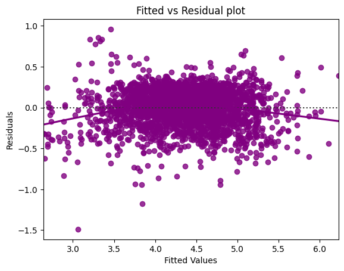

```python
# let's plot the fitted values vs residuals

sns.residplot(
    data=df_pred, x="Fitted Values", y="Residuals", color="purple", lowess=True
)
plt.xlabel("Fitted Values")
plt.ylabel("Residuals")
plt.title("Fitted vs Residual plot")
plt.show()
```

- The scatter plot shows the distribution of residuals (errors) vs fitted values (predicted values).
- If there exist any pattern in this plot, we consider it as signs of non-linearity in the data and a pattern means that the model doesn't capture non-linear effects.
- **We see no pattern in the plot above. Hence, the assumptions of linearity and independence are satisfied.**

### TEST FOR NORMALITY

**Why the test?**

- Error terms, or residuals, should be normally distributed. If the error terms are not normally distributed, confidence intervals of the coefficient estimates may become too wide or narrow. Once confidence interval becomes unstable, it leads to difficulty in estimating coefficients based on minimization of least squares. Non-normality suggests that there are a few unusual data points that must be studied closely to make a better model.

**How to check normality?**

- The shape of the histogram of residuals can give an initial idea about the normality.
- It can also be checked via a Q-Q plot of residuals. If the residuals follow a normal distribution, they will make a straight line plot, otherwise not.
- Other tests to check for normality includes the Shapiro-Wilk test.
  - Null hypothesis: Residuals are normally distributed
  - Alternate hypothesis: Residuals are not normally distributed

**How to fix if this assumption is not followed?**

- We can apply transformations like log, exponential, arcsinh, etc. as per our data.

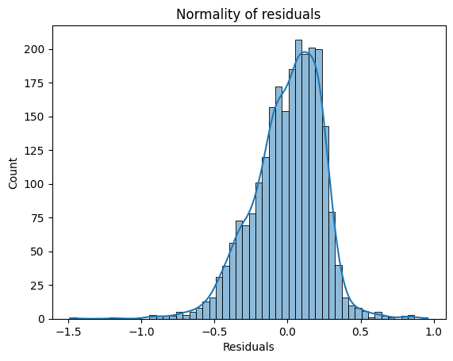

```python
sns.histplot(data=df_pred, x="Residuals", kde=True)
plt.title("Normality of residuals")
plt.show()
```

- The histogram of residuals does have a bell shape though it is not perfect.
- Let's check the Q-Q plot.

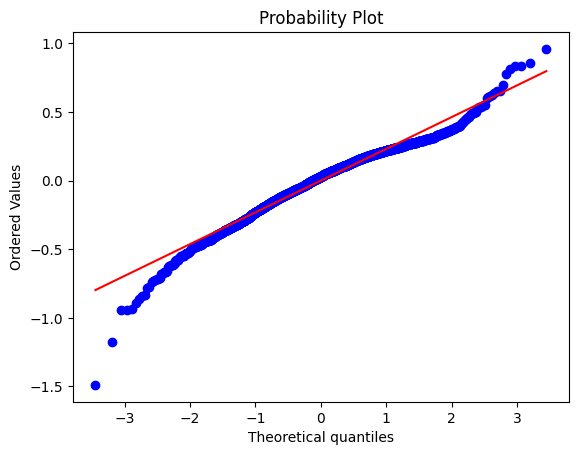

```python
import pylab
import scipy.stats as stats

stats.probplot(df_pred["Residuals"], dist="norm", plot=pylab)
plt.show()
```

- The residuals more or less follow a straight line except for the tails.
- Let's check the results of the Shapiro-Wilk test.

```python
stats.shapiro(df_pred["Residuals"])
```

```
ShapiroResult(statistic=0.9723459482192993, pvalue=3.2964258126392704e-21)
```

- Since p-value < 0.05, the residuals are not normal as per the Shapiro-Wilk test.
- Strictly speaking, the residuals are not normal.
- However, as an approximation, we can accept this distribution as close to being normal.
- **So, the assumption is satisfied.**

### TEST FOR HOMOSCEDASTICITY

- **Homoscedascity**: If the variance of the residuals is symmetrically distributed across the regression line, then the data is said to be homoscedastic.
- **Heteroscedascity**: If the variance is unequal for the residuals across the regression line, then the data is said to be heteroscedastic.

**Why the test?**

- The presence of non-constant variance in the error terms results in heteroscedasticity. Generally, non-constant variance arises in presence of outliers.

**How to check for homoscedasticity?**

- The residual vs fitted values plot can be looked at to check for homoscedasticity. In the case of heteroscedasticity, the residuals can form an arrow shape or any other non-symmetrical shape.
- The goldfeldquandt test can also be used. If we get a p-value > 0.05 we can say that the residuals are homoscedastic. Otherwise, they are heteroscedastic.
  - Null hypothesis: Residuals are homoscedastic
  - Alternate hypothesis: Residuals have heteroscedasticity

**How to fix if this assumption is not followed?**

- Heteroscedasticity can be fixed by adding other important features or making transformations.

```python
import statsmodels.stats.api as sms
from statsmodels.compat import lzip

name = ["F statistic", "p-value"]
test = sms.het_goldfeldquandt(df_pred["Residuals"], x_train3)
lzip(name, test)
```

```
[('F statistic', 1.0548551171951166), ('p-value', 0.17780196363306003)]
```

**Since p-value > 0.05, we can say that the residuals are homoscedastic. So, this assumption is satisfied.**

## Predictions on test data

Now that we have checked all the assumptions of linear regression and they are satisfied, let's go ahead with prediction.

```python
# predictions on the test set
pred = olsmod2.predict(x_test3)

df_pred_test = pd.DataFrame({"Actual": y_test, "Predicted": pred})
df_pred_test.sample(10, random_state=1)
```

|  | Actual | Predicted |
| --- | --- | --- |
| 1995 | 4.566741 | 4.379070 |
| 2341 | 3.696103 | 3.943470 |
| 1913 | 3.592093 | 3.787483 |
| 688 | 4.306495 | 4.151083 |
| 650 | 4.522115 | 5.104547 |
| 2291 | 4.259294 | 4.415589 |
| 40 | 4.997685 | 5.414345 |
| 1884 | 3.875359 | 4.082627 |
| 2538 | 4.206631 | 4.009101 |
| 45 | 5.380450 | 5.288885 |

- We can observe here that our model has returned pretty good prediction results, and the actual and predicted values are comparable

## Final Model

Let's recreate the final model and print it's summary to gain insights.

```python
x_train_final = x_train3.copy()
x_test_final = x_test3.copy()
```

```python
olsmodel_final = sm.OLS(y_train, x_train_final).fit()
print(olsmodel_final.summary())
```

```
                              OLS Regression Results
=================================================================================
Dep. Variable:     normalized_used_price   R-squared:                       0.838
Model:                               OLS   Adj. R-squared:                  0.838
Method:                    Least Squares   F-statistic:                     1248.
Date:                   Wed, 16 Aug 2023   Prob (F-statistic):               0.00
Time:                           14:31:26   Log-Likelihood:                 73.961
No. Observations:                   2417   AIC:                            -125.9
Df Residuals:                       2406   BIC:                            -62.23
Df Model:                             10
Covariance Type:               nonrobust
========================================================================================
                           coef    std err          t      P>|t|      [0.025      0.975]
----------------------------------------------------------------------------------------
const                    1.1527      0.042     27.482      0.000       1.070       1.235
screen_size              0.0453      0.001     31.458      0.000       0.042       0.048
main_camera_mp           0.0195      0.001     14.231      0.000       0.017       0.022
selfie_camera_mp         0.0147      0.001     16.496      0.000       0.013       0.016
ram                      0.0177      0.004      4.022      0.000       0.009       0.026
normalized_new_price     0.4188      0.011     39.827      0.000       0.398       0.439
brand_name_Nokia         0.0842      0.030      2.847      0.004       0.026       0.142
brand_name_Samsung      -0.0340      0.016     -2.073      0.038      -0.066      -0.002
brand_name_Sony         -0.0637      0.030     -2.089      0.037      -0.123      -0.004
brand_name_Xiaomi        0.0799      0.026      3.104      0.002       0.029       0.130
4g_yes                   0.0675      0.013      5.053      0.000       0.041       0.094
==============================================================================
Omnibus:                      207.745   Durbin-Watson:                   1.912
Prob(Omnibus):                  0.000   Jarque-Bera (JB):              377.372
Skew:                          -0.595   Prob(JB):                     1.13e-82
Kurtosis:                       4.526   Cond. No.                         182.
==============================================================================

Notes:
[1] Standard Errors assume that the covariance matrix of the errors is correctly specified.
```

```python
# checking model performance on train set (seen 70% data)
print("Training Performance\n")
olsmodel_final_train_perf = model_performance_regression(
    olsmodel_final, x_train_final, y_train
)
olsmodel_final_train_perf
```

```
Training Performance
```

|  | RMSE | MAE | R-squared | Adj. R-squared | MAPE |
| --- | --- | --- | --- | --- | --- |
| 0 | 0.234679 | 0.18414 | 0.838348 | 0.837609 | 4.415436 |

```python
# checking model performance on test set (seen 30% data)
print("Test Performance\n")
olsmodel_final_test_perf = model_performance_regression(
    olsmodel_final, x_test_final, y_test
)
olsmodel_final_test_perf
```

```
Test Performance
```

|  | RMSE | MAE | R-squared | Adj. R-squared | MAPE |
| --- | --- | --- | --- | --- | --- |
| 0 | 0.240387 | 0.185585 | 0.839786 | 0.838066 | 4.518847 |

- The model is able to explain ~83% of the variation in the data
- The train and test RMSE and MAE are low and comparable. So, our model is not suffering from overfitting
- The MAPE on the test set suggests we can predict within 4.51% of the normalised phone prices
- Hence, we can conclude the model *olsmodel_final* is good for prediction as well as inference purposes

## Actionable Insights and Recommendations

1. The model is able to explain ~83% of the variation in the data and within 4.51% of the normalized_used_phone price on the test data, which is good. This indicates that the model is good for prediction as well as inference purposes
1. If the screen_size of the phone increases by one unit, then its normalized price increases by 0.0453 units, all other variables held constant
1. If the main_camera_mp increases by one unit, then its price increases by 0.0195 units, all other variables held constant
1. If the selfie_camera_mp increases by one unit, then its price increases by 0.0147 units, all other variables held constant
2. If the ram increases by one unit, then its price increases by 0.0177 units, all other variables held constant
3. The brands Nokia and Xiaomi will be 0.0842 and 0.0799 units more whereas brands Samsung and Sony will be 0.0340 and 0.0637 units less.
4. The 4g enabled phones will be 0.0675 units more priced than the non-4g enabled ones.
5. Company can focus on the used phones with bigger screen sizes as the screen size increases, the used phone price also increases.
6. As the camera quality improves, the phone price also increases. So the company can look into adding phones with better camera (both main and selfie) pixels.
7. Relatively newer phones are almost close to new phone prices. So company should focus more on recent phones rather than very old phones.